# Prediction Assignment Writeup

Oluwatobi Olabiyi

Monday, May 11, 2015

## Introduction

This report contains the analysis of activity monitoring data obtained from wearable devices. The data is obtained from https://d396qusza40orc.cloudfront.net/predmachlearn. The task is to develop a model to predict accurately if someone lifts dumbbell correctly based on sensor data placed on the belt, arm, forearm of teh subject and also on the dumbbell itself.

Before processing the data we will first include the R packages required for our analysis, set the working directory and read in the data of interest.

```r
require(stats)
require(caret)
setwd("~/Documents/R_Programming/PML")
training <- read.csv("pml-training.csv")
testing <- read.csv("pml-testing.csv")
```

## Exploratory data analysis

Before embarking on prediction modeling,we will conduct basic exploratory data analysis.

We can take the summary and check the dimension of both the training and testing data sets

[output not shown]

[output cut: 313 more lines]

[output not shown]

[output not shown]

[output cut: 289 more lines]

[output not shown]

```r
dim(training)
```

```
## [1] 19622   160
```

```r
dim(testing)
```

```
## [1]  20 160
```

Both training and testing data sets consiste of 160 variables many of which contains NA. To decide wether to impute the NAs or not, it’s importantto find the percentage of the total data set that’s NA.

```r
mean(is.na(testing))
```

```
## [1] 0.625
```

```r
mean(is.na(training))
```

```
## [1] 0.4100856
```

Results shows that approximately 41% and 62.5% of training and testing sets contains NAs respectively. With these large proportion of NAs, it is not recommended to impute as the imputed values might introduce bias into the prediction model. Therefore, it is better to remove variables with only NA values as follows.

```r
pointer <- !is.na(testing)
nonaCount <- apply(pointer,2, sum)
nonaset <- nonaCount[nonaCount > 0]
nonaVar <- names(nonaset)
test <- testing[,nonaVar]
train0 <- training[,c(nonaVar[1:59], "classe")]
```

We can see that there are about 100 variables with only NA values which should not be included in our machine learning prediction. Having removed the variable with all NA values, the percentage NAs is now zero.

```r
mean(is.na(test))
```

```
## [1] 0
```

```r
mean(is.na(train0))
```

```
## [1] 0
```

## Regression Modeling

Since our test data set does not contain the outcome variable it’s important to have a cross validation set to be able to evaluate the out of sample error of the model. Here we will partition the trimmed training data set `train0` into training and cross validation data sets.

```r
set.seed(1234)
inTrain <- createDataPartition(train0$classe, p =0.7, list = F)
training0 <- train0[inTrain,]
cval0 <- train0[-inTrain,]
```

We will proceed to fit our model using the training set `training0` and then measure the out of sample error on the cross validation set `cval0`. Here we will fit the model using random forest algorithm. The choise of random forest algorithm (or any other tree based algorithm) is to be able to accurately fit the non-linearity between the outcomes and the regressors as can be seen in few pair plots of the variables.

The 59 variable can be grouped into 5 categories: * Information variables (1-7) * Belt measurement Variables (8-20) * Arm measurement variables (21-33) * Dumbbell measurement varables (34-46) * Forearm measurement variables (47 - 59) Each measurement variables contains 13 measurement type namely: roll, pirch, yaw, total accel, accel-x, accel-y, accel-z, gyro-x, gyro-y, gyro-z, magnet-x, magnet-y, magnet-z. We will make a pair plot according to the information categories to see if there are any redunndant or confounding variable tat should not be included in the model fit.

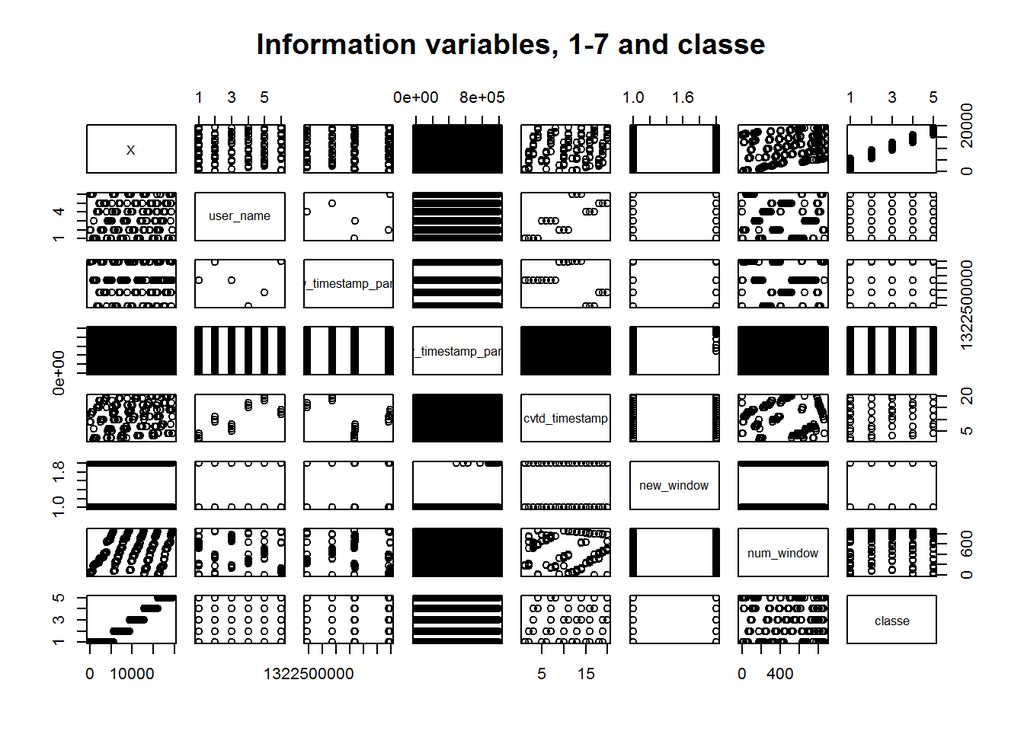

```r
pairs(train0[,c(1:7,60)], main = "Information variables, 1-7 and classe")
```

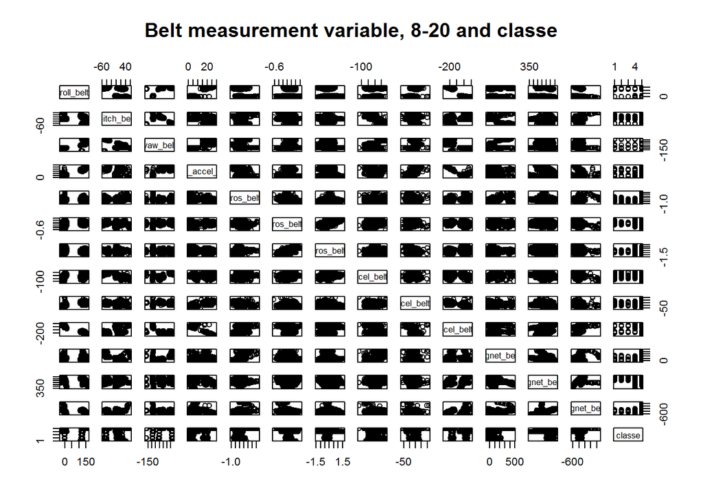

```r
pairs(train0[,c(8:20,60)], main = "Belt measurement variable, 8-20 and classe")
```

[figure not shown]

```r
pairs(train0[,c(21:33,60)], main = "Arm measurement variable, 8-20 and classe")
```

[figure not shown]

```r
pairs(train0[,c(34:46,60)], main = "Dumbbell measurement variable, 8-20 and classe")
```

[figure not shown]

```r
pairs(train0[,c(47:60)], main = "Forearm measurement variable, 8-20 and classe")
```

```r
modfit <- train(classe ~.-X, data = training0, method = "rf")
modfit$finalModel
```

```
FALSE
FALSE Call:
FALSE  randomForest(x = x, y = y, mtry = param$mtry)
FALSE                Type of random forest: classification
FALSE                      Number of trees: 500
FALSE No. of variables tried at each split: 41
FALSE
FALSE         OOB estimate of  error rate: 0.05%
FALSE Confusion matrix:
FALSE      A    B    C    D    E class.error
FALSE A 3906    0    0    0    0 0.000000000
FALSE B    0 2658    0    0    0 0.000000000
FALSE C    0    3 2392    1    0 0.001669449
FALSE D    0    0    2 2249    1 0.001332149
FALSE E    0    0    0    0 2525 0.000000000
```

```r
confusionMatrix(cval0$classe, predict(modfit,cval0))
```

```
FALSE Confusion Matrix and Statistics
FALSE
FALSE           Reference
FALSE Prediction    A    B    C    D    E
FALSE          A 1674    0    0    0    0
FALSE          B    2 1137    0    0    0
FALSE          C    0    1 1025    0    0
FALSE          D    0    0    1  963    0
FALSE          E    0    0    0    1 1081
FALSE
FALSE Overall Statistics
FALSE
FALSE                Accuracy : 0.9992
FALSE                  95% CI : (0.998, 0.9997)
FALSE     No Information Rate : 0.2848
FALSE     P-Value [Acc > NIR] : < 2.2e-16
FALSE
FALSE                   Kappa : 0.9989
FALSE  Mcnemar's Test P-Value : NA
FALSE
FALSE Statistics by Class:
FALSE
FALSE                      Class: A Class: B Class: C Class: D Class: E
FALSE Sensitivity            0.9988   0.9991   0.9990   0.9990   1.0000
FALSE Specificity            1.0000   0.9996   0.9998   0.9998   0.9998
FALSE Pos Pred Value         1.0000   0.9982   0.9990   0.9990   0.9991
FALSE Neg Pred Value         0.9995   0.9998   0.9998   0.9998   1.0000
FALSE Prevalence             0.2848   0.1934   0.1743   0.1638   0.1837
FALSE Detection Rate         0.2845   0.1932   0.1742   0.1636   0.1837
FALSE Detection Prevalence   0.2845   0.1935   0.1743   0.1638   0.1839
FALSE Balanced Accuracy      0.9994   0.9993   0.9994   0.9994   0.9999
```

```r
prediction <- predict(modfit,test)
print(prediction)
```

```
FALSE  [1] B A B A A E D B A A B C B A E E A B B B
FALSE Levels: A B C D E
```

We can see that both the in sample and out of sample standard errors are very low which shows good selection of regressors and training method. The final model is plotted below:

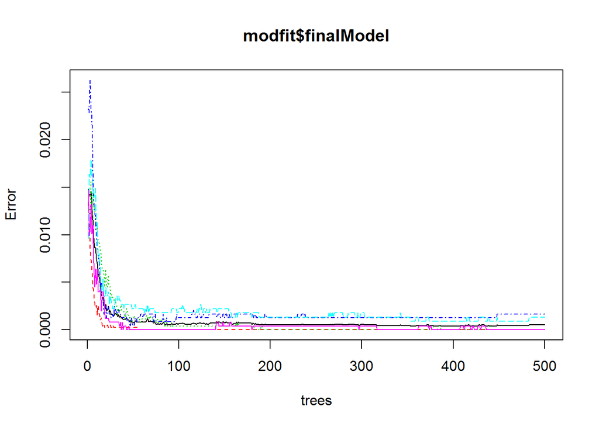

```r
plot(modfit$finalModel)
```

## Conclusion

Finally, the results from the test data set are converted into text files and uploaded.

```r
pml_write_files(prediction)
```

It’s worth mentioning the prediction accuracy based on the test data set is 100%.